# Introdução à Programação em Python

## Tópicos

- Operações Aritméticas
- Variáveis e Tipos
- Entrada e saída de dados
- Bibliotecas Extras

## Operações Aritméticas

O computador é essencialmente uma máquina de calcular. Para tanto temos diversas operações aritméticas disponíveis no Python:

- soma (`+`): `1+2`
- subtração (`-`): `2-1`
- multiplicação (`*`): `3*5`
- divisão (`/`): `7/2`
- exponenciação (`**`): `2**3`
- resto da divisão (`%`): `5%2`

Além disso temos disponível o comando `print` para mostrar na tela os resultados dessas operações:

```python
# todo texto escrito após "#" é um comentário e não é interpretado pelo Python
print 1+2  # realiza a operação 1+2 e imprime na tela
print 2-1
print 3*5
print 7/2
print 2**3
print 5%2
```

```
3
1
15
3
8
1
```

Repare que a operação 7/2 retorna um número inteiro, para retornar um valor real pelo menos um dos dois números também deve ser real.

```python
print 7/2.0
```

```
3.5
```

Note que a ordem que as operações são executadas seguem uma ordem de precedência, primeiro as operações de divisão e multiplicação, em seguida adição e subtração. Isso pode ser definido também através do uso de parênteses.

```python
print 1 + 2 * 3
print (1+2)*3
print 1 + (2*3)
```

```
7
9
7
```

Além das operações básicas temos algumas operações mais complexas disponíveis como padrão. Para usá-las utilizamos a biblioteca `math`. Indicamos isso para o computador com o comando `import math`.

As funções matemáticas disponíveis podem ser consultadas na [documentação](https://docs.python.org/2/library/math.html).

```python
import math

print math.sqrt(2.0) # raiz de 2
print math.exp(1.0), math.log(10) # e^1 e ln(10)
print math.log(math.exp(1.0)) # ln(e)
print math.cos(math.pi) # cos(pi)
```

```
1.41421356237
2.71828182846 2.30258509299
1.0
-1.0
```

Os tipos numéricos em Python são chamados de `int`, para números inteiros, e `float` para números reais.

```python
# Exercício 01
import math

# Vamos fazer algumas operações básicas: escreva o código logo abaixo das instruções, ao completar a tarefa aperte "shift+enter"
# e verifique se a resposta está de acordo com o esperado

# 1) A razão áurea é dada pela eq. (1 + raiz(5))/2, imprima o resultado
# resultado = 1.61803398875
print

# 2) A entropia é dada por:   -p*log(p) - (1-p)*log(1-p),
# Note que o logaritmo é na base 2, procure na documentação como calcular log2.
# Calcule a entropia para:

# p = 0.5, resultado = 1.0
print

# p = 1.0, resultado = nan
print

# p = 0.0, resultado = nan
print

# p = 0.4, resultado = 0.970950594455
print
```

Os valores `nan` indicam que o resultado não é um valor numérico válido, tendo sido ocasionado pelo cálculo de `log(0.0)`.

## Variáveis

Se quisermos fazer um programa que calcula a média aritmética entre dois números precisamos seguir os seguintes passos:

- Dados dois números
- Calcule a soma deles
- Divida o resultado por 2

Se soubermos quais são esses dois números, digamos que são 2 e 3, basta escrevermos o seguinte código:

```
print (2+3)/2.0
```

Porém seria interessante generalizar nosso algoritmo para quaisquer dois valores *x* e *y*. Da mesma forma que na matemática, podemos utilizar variáveis para generalizar uma expressão e alterar apenas os valores de tais variáveis. No computador, tais variáveis armazenam valores em memória para uso posterior.

Para utilizarmos variáveis no Python basta dar um nome a ela e, em seguida, atribuir um valor utilizando o operador "=". Uma vez que tal variável tem um valor, podemos realizar qualquer operação com ela:

```python
x = 10 # o computador armazena o valor 10 na variável de nome x
print x + 2
print x * 3
```

```
12
30
```

Dessa forma o nosso programa de média poderia ficar da seguinte forma:

```python
x = 2
y = 3
print (x+y)/2.0
```

```
2.5
```

Ao alterar os valores de `x` e `y`, o programa retorna o resultado da nova média. Podemos pedir que o usuário entre com os valores utilizando o comando `input()`.

Esse comando vai esperar que o usuário digite algum valor e o atribuirá em uma variável.

```python
x = input("digite o primeiro valor: ")
y = input("digite o segundo valor: ")
print (x+y)/2.0
```

```
digite o primeiro valor: 2
digite o segundo valor: 3
2.5
```

## Outros tipos de dados

Além dos tipos númericos int e float também podemos escrever números complexos da seguinte forma:

`2+3j`

As operações básicas funcionam também para esse tipo.

```python
x = 2+3j
y = 5+2j
print x + y
print x*y
```

```
(7+5j)
(4+19j)
```

Para as funções avançadas devemos utilizar a biblioteca [cmath](https://docs.python.org/2/library/cmath.html).:

```python
import cmath
cmath.sqrt(-2)
```

```
1.4142135623730951j
```

Além dos tipos numéricos temos também os tipos lógicos que podem conter o valor de verdadeiro (`True`) ou falso (`False`). Esses valores são gerados através de operadores relacionais:

- Igualdade: `1 == 2` => `False`
- Desigualdade: `1 != 2` => `True`
- Maior e Maior ou igual: `1 > 2`, `1 >= 2` => `False`
- Menor e Menor ou igual: `1 < 2`, `1 <= 2` => `True`

E compostos com operadores booleanos:

- E: `True and False` => `False`
- Ou: `True or False` => `True`
- Não: `not True` => `False`

```python
x = 1
y = 2
print x == y
print x != y
print x > y
print x < y
print x >= y
print x <= y
print x >= y or x != y
print x <= y and x != y # x < y?
print x <= y and not (x != y) # x >= y e x == y ==> x == y?
```

```
False
True
False
True
False
True
True
True
False
```

Temos também a opção de trabalhar com textos, ou *strings*, caracterizados por aspas simples ou duplas e capazes de manipular textos de diversas formas. Podemos usar os operadores `+` e `*`, representando concatenação e repetição:

```python
ola = "Olá"
espaco = " "
mundo = "Mundo"
print ola + espaco + mundo
print (ola + espaco) * 6 + mundo
```

```
Olá Mundo
Olá Olá Olá Olá Olá Olá Mundo
```

Existem maneiras mais interessantes de construir uma `string` que veremos futuramente.

E, finalmente, podemos criar uma lista de valores, colocando todos eles entre colchetes separados por vírgula. Nessa lista podemos colocar qualquer um dos tipos acima, inclusive misturando-os.

```python
lista = [1,2,3.0,'batata',True]
print lista, len(lista) # len = tamanho da lista
```

```
[1, 2, 3.0, 'batata', True] 5
```

Para acessar um elemento da lista utilizamos `[i]`, com `i` sendo o elemento que queremos acessar. A contagem do índice do elemento começa do 0. Isso também funciona para strings. Adicionalmente podemos utilizar faixa de valores usando [i:j] em que retornará os elementos entre [i,j[, excluindo o j.

```python
print lista[0]  # imprime o primeiro elemento da lista
print lista[0:3] # imprime os 3 primeiros elementos
print mundo[0:2] # imprime as duas primeiras letras da string
print lista[-1] # último elemento
```

```
1
[1, 2, 3.0]
Mu
True
```

Existem outros tipos mais avançados que veremos ao longo do curso.

Complete o código abaixo para realizar o que é pedido:

```python
#Exercício 02
import math
# 1) entre com o numero do mes do seu nascimento na variavel 'mes' e siga as instruções abaixo colocando o resultado
# na variável 'resultado'.
mes = input('Digite o mes do seu nascimento: ')
resultado = 0

# 1) multiplique o número por 2 e armazene na variavel de nome resultado

# 2) some 5 ao resultado e armazene nela mesma

# 3) multiplique por 50 armazenando em resultado

# 4) some sua idade ao resultado
idade = input('Digite sua idade: ')

# 5) subtraia resultado por 250

# o primeiro digito deve ser o mês e os dois últimos sua idade
print resultado
```

```
Digite o mes do seu nascimento: 28
Digite sua idade: 34
0
```

```python
#Exercício 03

# 1) Peça para o usuario digitar o nome e imprima "Ola <nome>, como vai?"
nome =
print

# 2) Crie uma lista com 3 zeros peça para o usuário digitar 2 valores, armazenando nas 2 primeiras
# posicoes. Calcule a media dos dois primeiros valores e armazene na terceira posição.

# utilize input() para capturar os valores
lista =

print lista
```

## Entrada e Saída de Dados

Durante essa primeira aula vimos sobre os comandos `input()` para capturar valores digitados pelo usuário e `print` para imprimir os valores dos resultados.

O comando `input()` aguarda por uma expressão válida do Python, seja ela um valor ou uma operação, retornando o resultado da expressão.

```python
x = input("Entre com uma expressão: ")
print x
```

```
Entre com uma expressão: 5+3
8
```

Por conta disso deve-se tomar cuidado com os valores que são digitados através desse comando. Em alguns ambientes, por segurança, a expressão digitada é convertida em string, ficando a cargo do programador fazer a conversão para o tipo necessário:

```python
x = float(input("Entre com um valor numérico: ")) # o valor digitado será um número em ponto flutuante
print x/2
```

```
Entre com um valor numérico: 10
5.0
```

Alguns dos comandos de conversão disponíveis são: `int()` para inteiros, `float()` para ponto flutuante e `str()` para strings.

```python
x = 10
print int(x) + 2
print float(x) * 2
print str(x) * 2
```

```
12
20.0
1010
```

O comando `print` permite escrever o valor de uma variável ou expressão na tela pulando para a próxima linha ao final. Esse comando permite a impressão de diversos valores na mesma linha separando-os por ",". Adicionalmente, ao terminar o comando com "," ele não pula para a próxima linha após a impressão.

```python
print 2 # imprime 2 e vai para a próxima linha
print 3, "ola", 4+5 # imprime múltiplos valores de diferentes tipos e vai para a próxima linha
print 1, 2, # imprime os dois valores mas não pula para a próxima linha
print 3,4 # continua impressão na mesma linha
```

```
2
3 ola 9
1 2 3 4
```

## Bibliotecas Extras

O Python conta com diversas bibliotecas que automatizam muitas tarefas e permitem realizarmos experimentos interessantes.

Uma biblioteca útil para o BC&T é a `matplotlib` que permite plotar gráficos diversos. Para usá-la no iPython Notebook basta executar o comando:

```python
%pylab inline
```

Vamos plotar alguns pontos de nossa função quadrática utilizando o comando `plot(x,y)`, onde **x** e **y** são listas com valores correspondentes a abscissa e ordenada, respectivamente.

Basicamente temos que **x** será uma lista de pontos que queremos plotar e **y** a aplicação da função `f(x) = x**2` em cada ponto de **x**.

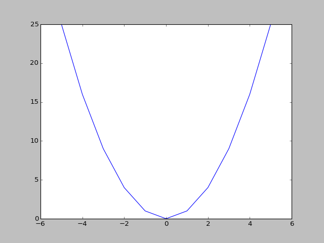

```python
%pylab nbagg
x = [-5,-4,-3,-2,-1,0,1,2,3,4,5]
y = [25,16,9,4,1,0,1,4,9,16,25]
plot(x,y)
```

Usualmente as bibliotecas, ou módulos, são importados através do comando `import NOME` e as funções das bibliotecas são chamadas precedidas pelo NOME do módulo. Vimos isso anteriormente com a biblioteca math:

```python
import math
print math.sqrt(2)
```

```
1.41421356237
```

Se soubermos exatamente as funções que iremos utilizar do módulo, podemos importá-los seletivamente com a sintaxe from NOME import FUNCAO, nesse caso não precisamos preceder a função com NOME para executá-la:

```python
from math import sqrt, exp
print sqrt(2), exp(3)
```

```
1.41421356237 20.0855369232
```

Finalmente podemos apelidar o nome do módulo para facilitar a chamada de funções:

```python
import math as mt
print mt.sqrt(2), mt.exp(3)
```

```
1.41421356237 20.0855369232
```